# Customer Churn Prediction Model

Victor Gomes

2026-01-21

# Executive Summary

This analysis builds a predictive model to identify customers at risk of churning, enabling proactive retention efforts.

**Objectives:** - Define and measure customer churn - Build predictive model using behavioral features - Identify high-risk customers for intervention - Quantify revenue at risk from churn - Provide targeted retention recommendations

# Introduction to Churn Prediction

## What is Customer Churn?

**Churn:** When a customer stops purchasing from the business.

## Why Predict Churn?

**Proactive Retention:** - Identify at-risk customers before they leave - Intervene with targeted campaigns - More cost-effective than re-acquisition

**Business Impact:** - Reduce customer attrition by 15-25% - Increase customer lifetime value - Optimize retention budget allocation - Improve forecasting accuracy

## Predictive Approach

**Model:** Logistic Regression (interpretable, proven effective)

**Features:** Behavioral indicators from historical data only - Recency (days since last purchase at prediction point) - Frequency (purchase count) - Monetary (total spend) - Trends (increasing/decreasing activity) - Engagement patterns

**Temporal Validation:** Features calculated from past data, churn measured in future period

# Setup

```r
library(tidyverse)
library(lubridate)
library(here)
library(scales)
library(knitr)
library(kableExtra)
library(viridis)
library(caret)       # Machine learning
library(pROC)        # ROC curves
library(ROCR)        # Additional ROC functions
```

# Data Loading

```r
# Load transaction data
transactions <- read_csv(here("data", "processed", "retail_customers_only.csv"))

cat("Data loaded:\n")
```

```
## Data loaded:
```

```r
cat("  Transactions:", nrow(transactions), "\n")
```

```
##   Transactions: 401571
```

```r
cat("  Unique Customers:", n_distinct(transactions$CustomerID), "\n")
```

```
##   Unique Customers: 4371
```

# Define Temporal Split

```r
# Define prediction point (90 days before dataset end)
analysis_date <- max(transactions$InvoiceDate)
prediction_point <- analysis_date - days(90)
churn_window <- 180  # Days of inactivity = churn

cat("\nTemporal Split Configuration:\n")
```

```
##
## Temporal Split Configuration:
```

```r
cat("  Analysis Date:", as.character(analysis_date), "\n")
```

```
##   Analysis Date: 2011-12-09 12:50:00
```

```r
cat("  Prediction Point:", as.character(prediction_point), "\n")
```

```
##   Prediction Point: 2011-09-10 12:50:00
```

```r
cat("  Churn Window:", churn_window, "days\n\n")
```

```
##   Churn Window: 180 days
```

```r
# Split data into historical and observation periods
historical_transactions <- transactions %>%
  filter(InvoiceDate <= prediction_point)

observation_transactions <- transactions %>%
  filter(InvoiceDate > prediction_point & InvoiceDate <= prediction_point + days(churn_window))

cat("Data Split:\n")
```

```
## Data Split:
```

```r
cat("  Historical transactions:", nrow(historical_transactions), "\n")
```

```
##   Historical transactions: 239570
```

```r
cat("  Observation transactions:", nrow(observation_transactions), "\n")
```

```
##   Observation transactions: 162001
```

# Feature Engineering

Create predictive features from historical data only (no data leakage).

```r
cat("\nCalculating customer features from historical data...\n")
```

```
##
## Calculating customer features from historical data...
```

```r
# Basic customer metrics from historical period
customer_features <- historical_transactions %>%
  filter(!IsReturn) %>%
  group_by(CustomerID) %>%
  summarize(
    # Transaction metrics
    Hist_TotalTransactions = n_distinct(InvoiceNo),
    Hist_TotalSpent = sum(TotalAmount),
    Hist_TotalItems = sum(Quantity),
    Hist_AOV = mean(TotalAmount),

    # Temporal metrics
    Hist_FirstPurchase = min(InvoiceDate),
    Hist_LastPurchase = max(InvoiceDate),
    Hist_CustomerLifetimeDays = as.numeric(difftime(max(InvoiceDate), min(InvoiceDate), units = "days")),

    # Frequency metrics
    Hist_AvgDaysBetweenPurchases = as.numeric(difftime(max(InvoiceDate), min(InvoiceDate), units = "days")) /
                                   pmax(n_distinct(InvoiceNo) - 1, 1),

    .groups = "drop"
  ) %>%
  mutate(
    # Recency at prediction point
    Hist_RecencyDays = as.numeric(difftime(prediction_point, Hist_LastPurchase, units = "days")),

    # Purchase frequency
    Hist_PurchaseFrequency = Hist_TotalTransactions / pmax(Hist_CustomerLifetimeDays / 30, 1)
  )

# Calculate temporal trends
customer_trends <- historical_transactions %>%
  filter(!IsReturn) %>%
  mutate(PurchaseMonth = floor_date(InvoiceDate, "month")) %>%
  group_by(CustomerID, PurchaseMonth) %>%
  summarize(
    Monthly_Transactions = n_distinct(InvoiceNo),
    Monthly_Spend = sum(TotalAmount),
    .groups = "drop"
  ) %>%
  group_by(CustomerID) %>%
  summarize(
    # Activity consistency
    Months_Active = n(),
    Avg_Monthly_Spend = mean(Monthly_Spend),
    Std_Monthly_Spend = sd(Monthly_Spend, na.rm = TRUE),

    # Recent vs historical comparison (last 3 months vs earlier)
    Recent_3Mo_Spend = sum(Monthly_Spend[PurchaseMonth >= prediction_point - months(3)]),
    Historical_Spend = sum(Monthly_Spend[PurchaseMonth < prediction_point - months(3)]),

    .groups = "drop"
  ) %>%
  mutate(
    # Spending trend
    Spend_Trend = ifelse(Historical_Spend > 0,
                         (Recent_3Mo_Spend / Historical_Spend) - 1, 0),
    Spend_Trend = pmin(pmax(Spend_Trend, -1), 3),

    # Spending volatility
    Spend_Volatility = ifelse(!is.na(Std_Monthly_Spend), Std_Monthly_Spend, 0)
  )

# Combine all features
model_data <- customer_features %>%
  left_join(customer_trends, by = "CustomerID") %>%
  mutate(
    # Handle NAs
    across(c(Months_Active, Avg_Monthly_Spend, Spend_Trend, Spend_Volatility), ~replace_na(., 0)),

    # Normalized features
    Recency_Normalized = log1p(Hist_RecencyDays),
    Frequency_Normalized = log1p(Hist_TotalTransactions),
    Monetary_Normalized = log1p(Hist_TotalSpent),
    AOV_Normalized = log1p(Hist_AOV),

    # Interaction features
    Recency_Frequency_Ratio = Hist_RecencyDays / pmax(Hist_AvgDaysBetweenPurchases, 1),
    Spend_per_Transaction = Hist_TotalSpent / pmax(Hist_TotalTransactions, 1)
  )

cat("\nFeature Engineering Complete\n")
```

```
##
## Feature Engineering Complete
```

```r
cat("  Total features:", ncol(model_data), "\n")
```

```
##   Total features: 24
```

```r
cat("  Customers:", nrow(model_data), "\n")
```

```
##   Customers: 3370
```

# Define Churn Labels

```r
cat("Defining churn labels from observation period...\n")
```

```
## Defining churn labels from observation period...
```

```r
# Identify customers who made purchases in observation period
active_customers <- observation_transactions %>%
  filter(!IsReturn) %>%
  group_by(CustomerID) %>%
  summarize(Had_Purchase = TRUE, .groups = "drop")

# Add churn labels
model_data <- model_data %>%
  left_join(active_customers, by = "CustomerID") %>%
  mutate(
    Churned = is.na(Had_Purchase),
    Churn_Label = ifelse(Churned, "Churned", "Active"),
    Churn_Binary = as.integer(Churned)
  ) %>%
  select(-Had_Purchase, -Hist_FirstPurchase, -Hist_LastPurchase) %>%
  filter(!is.na(Hist_TotalTransactions), Hist_TotalTransactions > 0)

# Churn summary
churn_summary <- model_data %>%
  count(Churn_Label) %>%
  mutate(Percentage = round(n / sum(n) * 100, 1))

cat("\nChurn Distribution:\n")
```

```
##
## Churn Distribution:
```

```r
churn_summary %>%
  kable() %>%
  kable_styling(bootstrap_options = c("striped", "hover"))
```

| Churn_Label | n | Percentage |
| --- | --- | --- |
| Active | 1921 | 57 |
| Churned | 1449 | 43 |

```r
cat("\nChurn Rate:", churn_summary$Percentage[churn_summary$Churn_Label == "Churned"], "%\n")
```

```
##
## Churn Rate: 43 %
```

# Exploratory Analysis: Churned vs Active

```r
# Compare key metrics between churned and active
comparison <- model_data %>%
  group_by(Churn_Label) %>%
  summarize(
    Customers = n(),
    Avg_Recency = round(mean(Hist_RecencyDays), 1),
    Avg_Frequency = round(mean(Hist_TotalTransactions), 1),
    Avg_Monetary = round(mean(Hist_TotalSpent), 2),
    Avg_AOV = round(mean(Hist_AOV), 2),
    Avg_Lifetime_Days = round(mean(Hist_CustomerLifetimeDays), 0),
    .groups = "drop"
  )

comparison %>%
  mutate(
    Avg_Monetary = dollar(Avg_Monetary, prefix = "£"),
    Avg_AOV = dollar(Avg_AOV, prefix = "£")
  ) %>%
  kable(caption = "Churned vs Active Customer Comparison") %>%
  kable_styling(bootstrap_options = c("striped", "hover"))
```

Churned vs Active Customer Comparison

| Churn_Label | Customers | Avg_Recency | Avg_Frequency | Avg_Monetary | Avg_AOV | Avg_Lifetime_Days |
| --- | --- | --- | --- | --- | --- | --- |
| Active | 1921 | 73.8 | 4.8 | £2,295.91 | £30.14 | 119 |
| Churned | 1449 | 123.1 | 1.9 | £712.59 | £103.42 | 47 |

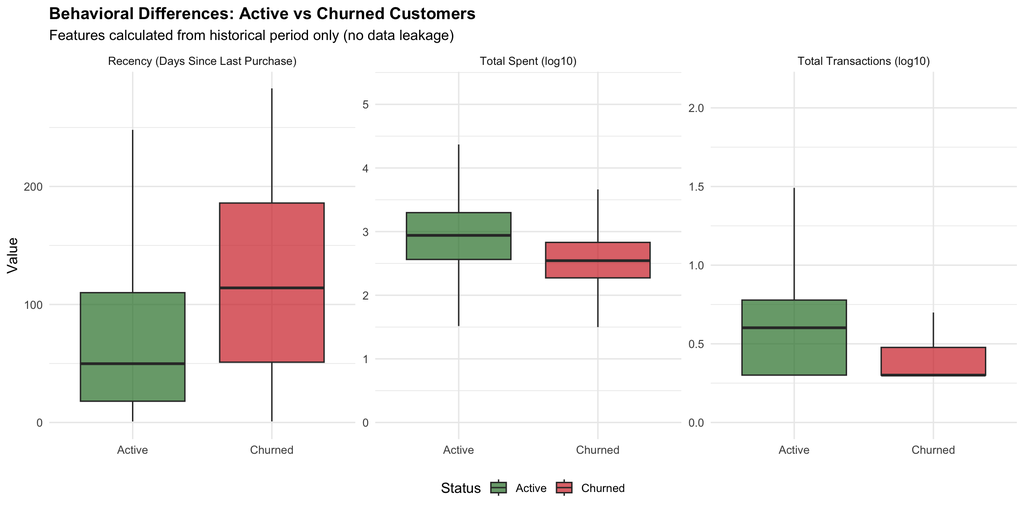

```r
# Visualize key differences with log transformation
behavioral_comparison <- model_data %>%
  select(CustomerID, Churn_Label, Hist_RecencyDays, Hist_TotalSpent, Hist_TotalTransactions) %>%
  mutate(
    Status = Churn_Label,
    TotalSpent_Log = log10(Hist_TotalSpent + 1),
    TotalTransactions_Log = log10(Hist_TotalTransactions + 1)
  ) %>%
  select(Status, Hist_RecencyDays, TotalSpent_Log, TotalTransactions_Log) %>%
  pivot_longer(
    cols = c(Hist_RecencyDays, TotalSpent_Log, TotalTransactions_Log),
    names_to = "Metric",
    values_to = "Value"
  ) %>%
  mutate(
    Metric = case_when(
      Metric == "Hist_RecencyDays" ~ "Recency (Days Since Last Purchase)",
      Metric == "TotalSpent_Log" ~ "Total Spent (log10)",
      Metric == "TotalTransactions_Log" ~ "Total Transactions (log10)"
    ),
    Metric = factor(Metric, levels = c("Recency (Days Since Last Purchase)",
                                       "Total Spent (log10)",
                                       "Total Transactions (log10)"))
  )

ggplot(behavioral_comparison, aes(x = Status, y = Value, fill = Status)) +
  geom_boxplot(outlier.shape = NA, alpha = 0.7) +
  coord_cartesian(ylim = c(0, NA)) +
  facet_wrap(~Metric, scales = "free_y", ncol = 3) +
  scale_fill_manual(values = c("Active" = "#2E7D32", "Churned" = "#D32F2F")) +
  labs(
    title = "Behavioral Differences: Active vs Churned Customers",
    subtitle = "Features calculated from historical period only (no data leakage)",
    x = NULL,
    y = "Value",
    fill = "Status"
  ) +
  theme_minimal(base_size = 12) +
  theme(
    plot.title = element_text(face = "bold", size = 14),
    legend.position = "bottom"
  )
```

# Train/Test Split

```r
set.seed(123)  # Reproducibility

# Create training and test sets (70/30 split)
train_index <- createDataPartition(model_data$Churned, p = 0.7, list = FALSE)

train_data <- model_data[train_index, ]
test_data <- model_data[-train_index, ]

cat("\nData Split:\n")
```

```
##
## Data Split:
```

```r
cat("  Training set:", nrow(train_data), "customers\n")
```

```
##   Training set: 2360 customers
```

```r
cat("  Test set:", nrow(test_data), "customers\n")
```

```
##   Test set: 1010 customers
```

```r
cat("  Training churn rate:",
    round(sum(train_data$Churned) / nrow(train_data) * 100, 1), "%\n")
```

```
##   Training churn rate: 43 %
```

```r
cat("  Test churn rate:",
    round(sum(test_data$Churned) / nrow(test_data) * 100, 1), "%\n")
```

```
##   Test churn rate: 43 %
```

# Logistic Regression Model

```r
# Build logistic regression model with historical features only
model_formula <- as.formula(
  Churned ~ Recency_Normalized + Frequency_Normalized + Monetary_Normalized +
    AOV_Normalized + Spend_Trend + Spend_Volatility + Months_Active +
    Recency_Frequency_Ratio + Spend_per_Transaction
)

logistic_model <- glm(model_formula,
                      data = train_data,
                      family = binomial(link = "logit"))

# Model summary
cat("\nLogistic Regression Model Summary:\n\n")
```

```
##
## Logistic Regression Model Summary:
```

```r
summary(logistic_model)
```

```
##
## Call:
## glm(formula = model_formula, family = binomial(link = "logit"),
##     data = train_data)
##
## Coefficients:
##                           Estimate Std. Error z value Pr(>|z|)
## (Intercept)              1.1686078  0.5228081   2.235  0.02540 *
## Recency_Normalized       0.0562823  0.0667001   0.844  0.39877
## Frequency_Normalized     0.1910692  0.3086263   0.619  0.53585
## Monetary_Normalized     -0.3092579  0.0967442  -3.197  0.00139 **
## AOV_Normalized           0.3086687  0.0620666   4.973 6.59e-07 ***
## Spend_Trend             -0.1286152  0.1023300  -1.257  0.20880
## Spend_Volatility        -0.0003436  0.0002782  -1.235  0.21682
## Months_Active           -0.4575980  0.0930379  -4.918 8.73e-07 ***
## Recency_Frequency_Ratio  0.0004478  0.0007739   0.579  0.56278
## Spend_per_Transaction    0.0001888  0.0001816   1.040  0.29852
## ---
## Signif. codes:  0 '***' 0.001 '**' 0.01 '*' 0.05 '.' 0.1 ' ' 1
##
## (Dispersion parameter for binomial family taken to be 1)
##
##     Null deviance: 3225.4  on 2359  degrees of freedom
## Residual deviance: 2720.3  on 2350  degrees of freedom
## AIC: 2740.3
##
## Number of Fisher Scoring iterations: 6
```

```r
# Feature importance
feature_importance <- data.frame(
  Feature = names(coef(logistic_model))[-1],
  Coefficient = coef(logistic_model)[-1],
  Abs_Coefficient = abs(coef(logistic_model)[-1])
) %>%
  arrange(desc(Abs_Coefficient))

cat("\n\nFeature Importance (by coefficient magnitude):\n\n")
```

```
##
##
## Feature Importance (by coefficient magnitude):
```

```r
feature_importance %>%
  mutate(
    Coefficient = round(Coefficient, 4),
    Abs_Coefficient = round(Abs_Coefficient, 4)
  ) %>%
  kable() %>%
  kable_styling(bootstrap_options = c("striped", "hover"))
```

|  | Feature | Coefficient | Abs_Coefficient |
| --- | --- | --- | --- |
| Months_Active | Months_Active | -0.4576 | 0.4576 |
| Monetary_Normalized | Monetary_Normalized | -0.3093 | 0.3093 |
| AOV_Normalized | AOV_Normalized | 0.3087 | 0.3087 |
| Frequency_Normalized | Frequency_Normalized | 0.1911 | 0.1911 |
| Spend_Trend | Spend_Trend | -0.1286 | 0.1286 |
| Recency_Normalized | Recency_Normalized | 0.0563 | 0.0563 |
| Recency_Frequency_Ratio | Recency_Frequency_Ratio | 0.0004 | 0.0004 |
| Spend_Volatility | Spend_Volatility | -0.0003 | 0.0003 |
| Spend_per_Transaction | Spend_per_Transaction | 0.0002 | 0.0002 |

[figure not shown]

```r
# Visualize feature importance
ggplot(feature_importance, aes(x = reorder(Feature, Abs_Coefficient), y = Coefficient)) +
  geom_col(aes(fill = Coefficient > 0), alpha = 0.8) +
  coord_flip() +
  scale_fill_manual(values = c("TRUE" = "#D32F2F", "FALSE" = "#2E7D32"),
                    labels = c("Increases Churn Risk", "Decreases Churn Risk")) +
  labs(
    title = "Feature Importance in Churn Prediction",
    subtitle = "Logistic regression coefficients",
    x = "Feature",
    y = "Coefficient",
    fill = "Effect"
  ) +
  theme_minimal(base_size = 12) +
  theme(plot.title = element_text(face = "bold", size = 14))
```

# Model Predictions

```r
# Predict on test set
test_data$Churn_Probability <- predict(logistic_model, newdata = test_data, type = "response")
test_data$Churn_Prediction <- ifelse(test_data$Churn_Probability > 0.5, TRUE, FALSE)

# Predict on full dataset for business use
model_data$Churn_Probability <- predict(logistic_model, newdata = model_data, type = "response")
model_data$Churn_Prediction <- ifelse(model_data$Churn_Probability > 0.5, TRUE, FALSE)
model_data$Risk_Category <- cut(model_data$Churn_Probability,
                                 breaks = c(0, 0.25, 0.5, 0.75, 1),
                                 labels = c("Low Risk", "Medium Risk", "High Risk", "Critical Risk"),
                                 include.lowest = TRUE)

cat("\nPredictions Complete\n")
```

```
##
## Predictions Complete
```

```r
cat("  Average churn probability:",
    round(mean(model_data$Churn_Probability) * 100, 1), "%\n")
```

```
##   Average churn probability: 43.1 %
```

# Model Evaluation

```r
# Confusion matrix
conf_matrix <- confusionMatrix(
  factor(test_data$Churn_Prediction, levels = c(FALSE, TRUE)),
  factor(test_data$Churned, levels = c(FALSE, TRUE)),
  positive = "TRUE"
)

cat("\nConfusion Matrix:\n\n")
```

```
##
## Confusion Matrix:
```

```r
print(conf_matrix$table)
```

```
##           Reference
## Prediction FALSE TRUE
##      FALSE   399  139
##      TRUE    177  295
```

```r
cat("\n\nModel Performance Metrics:\n")
```

```
##
##
## Model Performance Metrics:
```

```r
cat("  Accuracy:", round(conf_matrix$overall['Accuracy'] * 100, 1), "%\n")
```

```
##   Accuracy: 68.7 %
```

```r
cat("  Sensitivity (Recall):", round(conf_matrix$byClass['Sensitivity'] * 100, 1), "%\n")
```

```
##   Sensitivity (Recall): 68 %
```

```r
cat("  Specificity:", round(conf_matrix$byClass['Specificity'] * 100, 1), "%\n")
```

```
##   Specificity: 69.3 %
```

```r
cat("  Precision:", round(conf_matrix$byClass['Precision'] * 100, 1), "%\n")
```

```
##   Precision: 62.5 %
```

```r
cat("  F1 Score:", round(conf_matrix$byClass['F1'] * 100, 1), "%\n")
```

```
##   F1 Score: 65.1 %
```

## ROC Curve

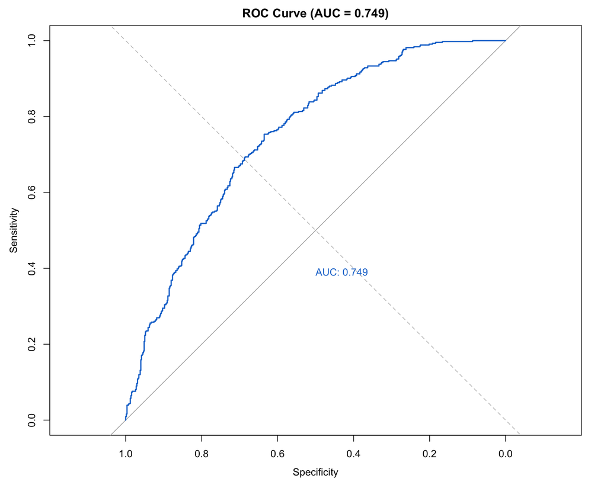

```r
# ROC curve
roc_obj <- roc(test_data$Churned, test_data$Churn_Probability)
auc_value <- auc(roc_obj)

# Plot ROC
plot(roc_obj,
     main = paste0("ROC Curve (AUC = ", round(auc_value, 3), ")"),
     col = "#1976D2",
     lwd = 2,
     print.auc = TRUE,
     print.auc.y = 0.4)
abline(a = 0, b = 1, lty = 2, col = "gray")
```

```r
cat("\nAUC (Area Under Curve):", round(auc_value, 3), "\n")
```

```
##
## AUC (Area Under Curve): 0.749
```

```r
cat("Interpretation:", ifelse(auc_value > 0.8, "Excellent",
                              ifelse(auc_value > 0.7, "Good", "Fair")), "\n")
```

```
## Interpretation: Good
```

# Risk Segmentation

```r
# Analyze risk categories
risk_summary <- model_data %>%
  group_by(Risk_Category) %>%
  summarize(
    Customers = n(),
    Pct_Customers = round(n() / nrow(model_data) * 100, 1),
    Avg_Churn_Prob = round(mean(Churn_Probability) * 100, 1),
    Actual_Churned = sum(Churned),
    Actual_Churn_Rate = round(sum(Churned) / n() * 100, 1),
    Total_Revenue_at_Risk = sum(Hist_TotalSpent),
    Avg_CLV = mean(Hist_TotalSpent),
    .groups = "drop"
  ) %>%
  arrange(desc(Avg_Churn_Prob))

risk_summary %>%
  mutate(
    Total_Revenue_at_Risk = dollar(Total_Revenue_at_Risk, prefix = "£"),
    Avg_CLV = dollar(Avg_CLV, prefix = "£")
  ) %>%
  kable(caption = "Churn Risk Segmentation") %>%
  kable_styling(bootstrap_options = c("striped", "hover"))
```

Churn Risk Segmentation

| Risk_Category | Customers | Pct_Customers | Avg_Churn_Prob | Actual_Churned | Actual_Churn_Rate | Total_Revenue_at_Risk | Avg_CLV |
| --- | --- | --- | --- | --- | --- | --- | --- |
| Critical Risk | 86 | 2.6 | 79.3 | 66 | 76.7 | £196,449 | £2,284.29 |
| High Risk | 1454 | 43.1 | 61.8 | 898 | 61.8 | £543,805 | £374.01 |
| Medium Risk | 1033 | 30.7 | 37.9 | 386 | 37.4 | £960,959 | £930.26 |
| Low Risk | 797 | 23.6 | 12.1 | 99 | 12.4 | £3,741,766 | £4,694.81 |

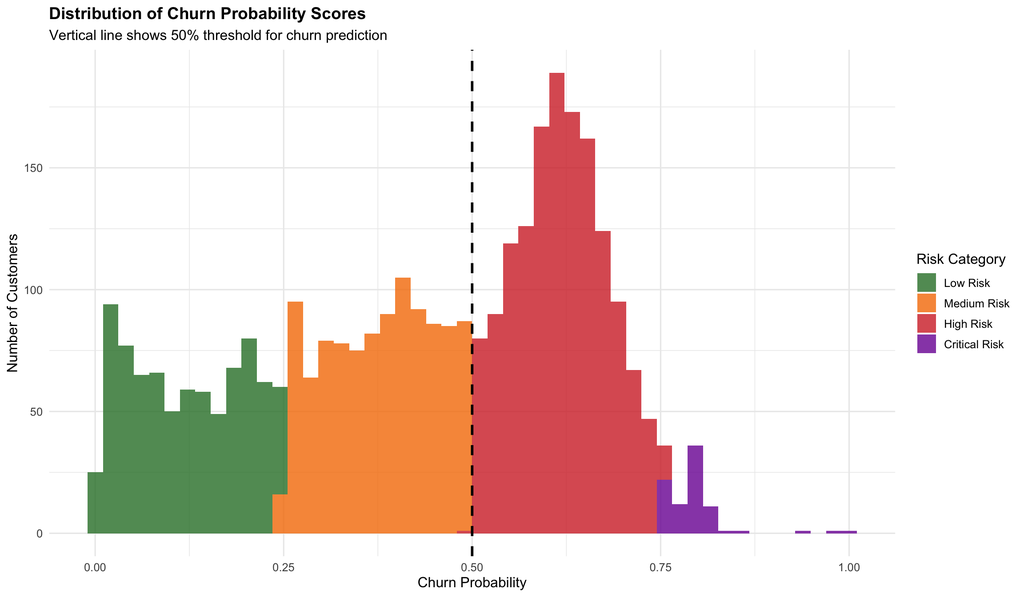

```r
# Visualize risk distribution
ggplot(model_data, aes(x = Churn_Probability, fill = Risk_Category)) +
  geom_histogram(bins = 50, alpha = 0.8) +
  geom_vline(xintercept = 0.5, linetype = "dashed", color = "black", linewidth = 1) +
  scale_fill_manual(values = c("Low Risk" = "#2E7D32", "Medium Risk" = "#F57C00",
                                "High Risk" = "#D32F2F", "Critical Risk" = "#7B1FA2")) +
  labs(
    title = "Distribution of Churn Probability Scores",
    subtitle = "Vertical line shows 50% threshold for churn prediction",
    x = "Churn Probability",
    y = "Number of Customers",
    fill = "Risk Category"
  ) +
  theme_minimal(base_size = 12) +
  theme(plot.title = element_text(face = "bold", size = 14))
```

# High-Risk Customer Analysis

```r
# Focus on high and critical risk customers
high_risk <- model_data %>%
  filter(Risk_Category %in% c("High Risk", "Critical Risk"))

cat("\nHIGH-RISK CUSTOMER ANALYSIS\n")
```

```
##
## HIGH-RISK CUSTOMER ANALYSIS
```

```r
cat(rep("=", 70), "\n\n")
cat("High/Critical Risk Customers:", nrow(high_risk), "\n")
```

```
## High/Critical Risk Customers: 1540
```

```r
cat("Percentage of base:", round(nrow(high_risk) / nrow(model_data) * 100, 1), "%\n")
```

```
## Percentage of base: 45.7 %
```

```r
cat("Revenue at risk:", dollar(sum(high_risk$Hist_TotalSpent), prefix = "£"), "\n")
```

```
## Revenue at risk: £740,254
```

```r
cat("Average customer value:", dollar(mean(high_risk$Hist_TotalSpent), prefix = "£"), "\n\n")
```

```
## Average customer value: £480.68
```

```r
# Characteristics of high-risk customers
cat("Behavioral Characteristics:\n")
```

```
## Behavioral Characteristics:
```

```r
cat("  Avg days since last purchase:", round(mean(high_risk$Hist_RecencyDays), 1), "\n")
```

```
##   Avg days since last purchase: 144.8
```

```r
cat("  Avg lifetime purchases:", round(mean(high_risk$Hist_TotalTransactions), 1), "\n")
```

```
##   Avg lifetime purchases: 1.2
```

```r
cat("  Avg total spent:", dollar(mean(high_risk$Hist_TotalSpent), prefix = "£"), "\n")
```

```
##   Avg total spent: £480.68
```

```r
cat("  Avg months active:", round(mean(high_risk$Months_Active, na.rm = TRUE), 1), "\n")
```

```
##   Avg months active: 1.1
```

## Top 20 Highest Risk Customers

```r
# Identify top risk customers for immediate action
top_risk <- model_data %>%
  arrange(desc(Churn_Probability)) %>%
  head(20) %>%
  select(CustomerID, Churn_Probability, Risk_Category, Hist_RecencyDays,
         Hist_TotalTransactions, Hist_TotalSpent)

top_risk %>%
  mutate(
    Churn_Probability = percent(Churn_Probability, accuracy = 0.1),
    Hist_TotalSpent = dollar(Hist_TotalSpent, prefix = "£")
  ) %>%
  kable(caption = "Top 20 Customers at Highest Churn Risk") %>%
  kable_styling(bootstrap_options = c("striped", "hover"), font_size = 10) %>%
  scroll_box(width = "100%")
```

Top 20 Customers at Highest Churn Risk

| CustomerID | Churn_Probability | Risk_Category | Hist_RecencyDays | Hist_TotalTransactions | Hist_TotalSpent |
| --- | --- | --- | --- | --- | --- |
| 12346 | 100.0% | Critical Risk | 235.11736 | 1 | £77,183.60 |
| 15098 | 97.3% | Critical Risk | 91.88681 | 3 | £39,916.50 |
| 15749 | 93.5% | Critical Risk | 144.97917 | 3 | £44,534.30 |
| 13135 | 86.6% | Critical Risk | 106.08194 | 1 | £3,096.00 |
| 16754 | 82.9% | Critical Risk | 281.80000 | 1 | £2,002.40 |
| 13270 | 82.1% | Critical Risk | 275.91458 | 1 | £590.00 |
| 18080 | 81.4% | Critical Risk | 152.11111 | 1 | £841.50 |
| 17291 | 81.4% | Critical Risk | 217.99028 | 1 | £550.80 |
| 18133 | 81.3% | Critical Risk | 121.94167 | 1 | £931.50 |
| 18233 | 81.2% | Critical Risk | 235.17083 | 1 | £440.00 |
| 17925 | 81.1% | Critical Risk | 282.11111 | 1 | £244.08 |
| 14608 | 80.9% | Critical Risk | 271.91736 | 1 | £204.00 |
| 15070 | 80.7% | Critical Risk | 282.06042 | 1 | £106.20 |
| 15510 | 80.7% | Critical Risk | 240.02778 | 1 | £250.00 |
| 13747 | 80.7% | Critical Risk | 283.09236 | 1 | £79.60 |
| 18113 | 80.6% | Critical Risk | 278.01319 | 1 | £76.32 |
| 15562 | 80.6% | Critical Risk | 261.12153 | 1 | £134.55 |
| 14576 | 80.5% | Critical Risk | 281.79097 | 1 | £35.40 |
| 17752 | 80.5% | Critical Risk | 268.85486 | 1 | £80.64 |
| 15823 | 80.5% | Critical Risk | 281.90417 | 1 | £15.00 |

# Business Impact & ROI

```r
cat("\n")
```

```r
cat(rep("=", 70), "\n")
cat("                    BUSINESS IMPACT ANALYSIS\n")
```

```
##                     BUSINESS IMPACT ANALYSIS
```

```r
cat(rep("=", 70), "\n\n")
```

```r
# Calculate retention campaign scenarios
total_high_risk <- sum(model_data$Risk_Category %in% c("High Risk", "Critical Risk"))
revenue_at_risk <- sum((model_data %>%
  filter(Risk_Category %in% c("High Risk", "Critical Risk")))$Hist_TotalSpent)

cat("CHURN RISK ASSESSMENT:\n\n")
```

```
## CHURN RISK ASSESSMENT:
```

```r
cat(sprintf("  • High/Critical risk customers: %s\n", comma(total_high_risk)))
```

```
##   • High/Critical risk customers: 1,540
```

```r
cat(sprintf("  • Total revenue at risk: %s\n", dollar(revenue_at_risk, prefix = "£")))
```

```
##   • Total revenue at risk: £740,254
```

```r
cat(sprintf("  • Average value per at-risk customer: %s\n\n",
            dollar(revenue_at_risk / total_high_risk, prefix = "£")))
```

```
##   • Average value per at-risk customer: £480.68
```

```r
# Retention scenarios
cat("RETENTION CAMPAIGN SCENARIOS:\n\n")
```

```
## RETENTION CAMPAIGN SCENARIOS:
```

```r
# Scenario 1: Save 30% of high-risk customers
save_rate_1 <- 0.30
saved_revenue_1 <- revenue_at_risk * save_rate_1
campaign_cost_1 <- total_high_risk * 20  # £20 per customer

cat("Scenario 1: Conservative (30% save rate)\n")
```

```
## Scenario 1: Conservative (30% save rate)
```

```r
cat(sprintf("  • Customers saved: %s\n", comma(round(total_high_risk * save_rate_1))))
```

```
##   • Customers saved: 462
```

```r
cat(sprintf("  • Revenue retained: %s\n", dollar(saved_revenue_1, prefix = "£")))
```

```
##   • Revenue retained: £222,076
```

```r
cat(sprintf("  • Campaign cost (£20/customer): %s\n", dollar(campaign_cost_1, prefix = "£")))
```

```
##   • Campaign cost (£20/customer): £30,800
```

```r
cat(sprintf("  • Net benefit: %s\n", dollar(saved_revenue_1 - campaign_cost_1, prefix = "£")))
```

```
##   • Net benefit: £191,276
```

```r
cat(sprintf("  • ROI: %.1fx\n\n", saved_revenue_1 / campaign_cost_1))
```

```
##   • ROI: 7.2x
```

```r
# Scenario 2: Save 50% of high-risk customers
save_rate_2 <- 0.50
saved_revenue_2 <- revenue_at_risk * save_rate_2
campaign_cost_2 <- total_high_risk * 35  # £35 per customer (more intensive)

cat("Scenario 2: Aggressive (50% save rate)\n")
```

```
## Scenario 2: Aggressive (50% save rate)
```

```r
cat(sprintf("  • Customers saved: %s\n", comma(round(total_high_risk * save_rate_2))))
```

```
##   • Customers saved: 770
```

```r
cat(sprintf("  • Revenue retained: %s\n", dollar(saved_revenue_2, prefix = "£")))
```

```
##   • Revenue retained: £370,127
```

```r
cat(sprintf("  • Campaign cost (£35/customer): %s\n", dollar(campaign_cost_2, prefix = "£")))
```

```
##   • Campaign cost (£35/customer): £53,900
```

```r
cat(sprintf("  • Net benefit: %s\n", dollar(saved_revenue_2 - campaign_cost_2, prefix = "£")))
```

```
##   • Net benefit: £316,227
```

```r
cat(sprintf("  • ROI: %.1fx\n\n", saved_revenue_2 / campaign_cost_2))
```

```
##   • ROI: 6.9x
```

```r
cat(rep("=", 70), "\n\n")
```

# Retention Recommendations

```r
cat("TARGETED RETENTION STRATEGIES BY RISK LEVEL\n")
```

```
## TARGETED RETENTION STRATEGIES BY RISK LEVEL
```

```r
cat(rep("=", 70), "\n\n")
cat("🔴 CRITICAL RISK (Churn Prob >75%)\n")
```

```
## 🔴 CRITICAL RISK (Churn Prob >75%)
```

```r
critical_count <- sum(model_data$Risk_Category == "Critical Risk")
cat(sprintf("   • %s customers\n", comma(critical_count)))
```

```
##    • 86 customers
```

```r
cat("   Actions:\n")
```

```
##    Actions:
```

```r
cat("   - Immediate personal outreach (phone calls)\n")
```

```
##    - Immediate personal outreach (phone calls)
```

```r
cat("   - Maximum discount offer (30-40% off)\n")
```

```
##    - Maximum discount offer (30-40% off)
```

```r
cat("   - Free shipping for 6 months\n")
```

```
##    - Free shipping for 6 months
```

```r
cat("   - Personal account manager\n")
```

```
##    - Personal account manager
```

```r
cat("   - Win-back guarantee (refund if not satisfied)\n")
```

```
##    - Win-back guarantee (refund if not satisfied)
```

```r
cat("   Budget: £50-75 per customer\n\n")
```

```
##    Budget: £50-75 per customer
```

```r
cat("🟠 HIGH RISK (Churn Prob 50-75%)\n")
```

```
## 🟠 HIGH RISK (Churn Prob 50-75%)
```

```r
high_count <- sum(model_data$Risk_Category == "High Risk")
cat(sprintf("   • %s customers\n", comma(high_count)))
```

```
##    • 1,454 customers
```

```r
cat("   Actions:\n")
```

```
##    Actions:
```

```r
cat("   - Personalized email campaign\n")
```

```
##    - Personalized email campaign
```

```r
cat("   - 20-25% discount offer\n")
```

```
##    - 20-25% discount offer
```

```r
cat("   - Product recommendations based on past purchases\n")
```

```
##    - Product recommendations based on past purchases
```

```r
cat("   - Free shipping on next order\n")
```

```
##    - Free shipping on next order
```

```r
cat("   - Feedback survey (understand issues)\n")
```

```
##    - Feedback survey (understand issues)
```

```r
cat("   Budget: £25-35 per customer\n\n")
```

```
##    Budget: £25-35 per customer
```

```r
cat("🟡 MEDIUM RISK (Churn Prob 25-50%)\n")
```

```
## 🟡 MEDIUM RISK (Churn Prob 25-50%)
```

```r
medium_count <- sum(model_data$Risk_Category == "Medium Risk")
cat(sprintf("   • %s customers\n", comma(medium_count)))
```

```
##    • 1,033 customers
```

```r
cat("   Actions:\n")
```

```
##    Actions:
```

```r
cat("   - Automated re-engagement emails\n")
```

```
##    - Automated re-engagement emails
```

```r
cat("   - 10-15% discount offer\n")
```

```
##    - 10-15% discount offer
```

```r
cat("   - \"We miss you\" messaging\n")
```

```
##    - "We miss you" messaging
```

```r
cat("   - Highlight new products\n")
```

```
##    - Highlight new products
```

```r
cat("   Budget: £10-15 per customer\n\n")
```

```
##    Budget: £10-15 per customer
```

```r
cat("🟢 LOW RISK (Churn Prob <25%)\n")
```

```
## 🟢 LOW RISK (Churn Prob <25%)
```

```r
low_count <- sum(model_data$Risk_Category == "Low Risk")
cat(sprintf("   • %s customers\n", comma(low_count)))
```

```
##    • 797 customers
```

```r
cat("   Actions:\n")
```

```
##    Actions:
```

```r
cat("   - Standard marketing automation\n")
```

```
##    - Standard marketing automation
```

```r
cat("   - Loyalty program benefits\n")
```

```
##    - Loyalty program benefits
```

```r
cat("   - New product announcements\n")
```

```
##    - New product announcements
```

```r
cat("   Budget: £3-5 per customer\n\n")
```

```
##    Budget: £3-5 per customer
```

```r
cat(rep("=", 70), "\n\n")
```

# Export Predictions

```r
# Export churn predictions for CRM
churn_export <- model_data %>%
  select(
    CustomerID,
    Churn_Probability,
    Risk_Category,
    Churned,
    Hist_RecencyDays,
    Hist_TotalTransactions,
    Hist_TotalSpent,
    Hist_AOV,
    Months_Active
  ) %>%
  arrange(desc(Churn_Probability))

export_path <- here("data", "processed", "churn_predictions.csv")
write_csv(churn_export, export_path)

cat("✓ Churn predictions exported to:", export_path, "\n")
```

```
## ✓ Churn predictions exported to: /Users/joaovictorgomes/Documents/ecommerce-customer-analytics/data/processed/churn_predictions.csv
```

```r
cat("  Customers:", nrow(churn_export), "\n\n")
```

```
##   Customers: 3370
```

```r
cat("Ready for:\n")
```

```
## Ready for:
```

```r
cat("  • CRM integration\n")
```

```
##   • CRM integration
```

```r
cat("  • Retention campaign targeting\n")
```

```
##   • Retention campaign targeting
```

```r
cat("  • Customer service prioritization\n")
```

```
##   • Customer service prioritization
```

```r
cat("  • Sales team alerts\n")
```

```
##   • Sales team alerts
```

# Summary & Key Takeaways

```r
cat("\n")
```

```r
cat(rep("=", 70), "\n")
cat("            CHURN PREDICTION MODEL COMPLETE\n")
```

```
##             CHURN PREDICTION MODEL COMPLETE
```

```r
cat(rep("=", 70), "\n\n")
cat("✅ ACHIEVEMENTS:\n\n")
```

```
## ✅ ACHIEVEMENTS:
```

```r
cat("  1. Built logistic regression churn prediction model\n")
```

```
##   1. Built logistic regression churn prediction model
```

```r
cat(sprintf("  2. Model accuracy: %.1f%%\n", conf_matrix$overall['Accuracy'] * 100))
```

```
##   2. Model accuracy: 68.7%
```

```r
cat(sprintf("  3. AUC score: %.3f (%s)\n", auc_value,
            ifelse(auc_value > 0.8, "Excellent", ifelse(auc_value > 0.7, "Good", "Fair"))))
```

```
##   3. AUC score: 0.749 (Good)
```

```r
cat(sprintf("  4. Identified %s high-risk customers\n", comma(total_high_risk)))
```

```
##   4. Identified 1,540 high-risk customers
```

```r
cat(sprintf("  5. Quantified %s in at-risk revenue\n\n", dollar(revenue_at_risk, prefix = "£")))
```

```
##   5. Quantified £740,254 in at-risk revenue
```

```r
cat("🎯 KEY INSIGHTS:\n\n")
```

```
## 🎯 KEY INSIGHTS:
```

```r
cat(sprintf("  • %.1f%% of customers at high/critical churn risk\n",
            total_high_risk / nrow(model_data) * 100))
```

```
##   • 45.7% of customers at high/critical churn risk
```

```r
cat(sprintf("  • Revenue at risk: %s\n", dollar(revenue_at_risk, prefix = "£")))
```

```
##   • Revenue at risk: £740,254
```

```r
cat(sprintf("  • Top risk factor: %s\n", feature_importance$Feature[1]))
```

```
##   • Top risk factor: Months_Active
```

```r
cat(sprintf("  • Retention ROI: %.1fx (conservative scenario)\n", saved_revenue_1 / campaign_cost_1))
```

```
##   • Retention ROI: 7.2x (conservative scenario)
```

```r
cat("\n💡 NEXT STEPS:\n\n")
```

```
##
## 💡 NEXT STEPS:
```

```r
cat("  1. Launch immediate outreach to critical risk customers\n")
```

```
##   1. Launch immediate outreach to critical risk customers
```

```r
cat("  2. Implement risk-based retention campaigns\n")
```

```
##   2. Implement risk-based retention campaigns
```

```r
cat("  3. Integrate churn scores into CRM\n")
```

```
##   3. Integrate churn scores into CRM
```

```r
cat("  4. Monthly model retraining and updates\n")
```

```
##   4. Monthly model retraining and updates
```

```r
cat("  5. Track campaign effectiveness and adjust\n\n")
```

```
##   5. Track campaign effectiveness and adjust
```

```r
cat(rep("=", 70), "\n\n")
```

**✅ Churn Prediction Model Complete!**

*This model enables proactive customer retention and optimized intervention strategies.*